# Hand-out: Konstruksi & Agregasi Data SUSENAS–PODES dengan R

Studi kasus: Balita Sakit (SUSENAS) & Posyandu (PODES) — data sintetis 119 kab/kota Pulau Jawa

Author

Training R UNNES

Published

July 8, 2026

**ImportantDisklaimer: data sintetis, bukan data asli**

Seluruh data pada hand-out ini adalah **data sintetis** — dibangkitkan komputer **khusus untuk keperluan pelatihan**. Struktur file, nama variabel (`R101`, `R407`, `R1102`, `R705A`, dst.), dan alur pengolahan meniru SUSENAS KOR Maret 2023 dan PODES 2021, tetapi seluruh angka, indikator, dan hasil regresi **tidak menggambarkan kondisi riil kabupaten/kota mana pun** dan **bukan data resmi BPS**. Jangan mengutip angka dari materi ini. Untuk data sesungguhnya, ajukan akses data mikro resmi BPS melalui silastik.bps.go.id.

# 1 Gambaran umum alur kerja

Analisis kabupaten/kota berbasis data mikro BPS selalu melewati tiga tahap:

1. **Konstruksi** — dari file mentah (satu baris = satu individu/rumah tangga/desa) dibentuk *dataset per variabel* yang bersih: kode wilayah, variabel hasil recode, bobot, dan label.
2. **Agregasi** — dataset per variabel diringkas menjadi satu angka per kabupaten/kota. Untuk **survei** (SUSENAS) wajib memakai **bobot** (`FWT` untuk individu, `WERT` untuk rumah tangga); untuk **sensus** (PODES) cukup penjumlahan.
3. **Penggabungan** — semua indikator kabupaten di-*merge* dengan kunci `kode_kab` menjadi satu tabel basis analisis (119 baris untuk Pulau Jawa).

Hand-out ini mencontohkan satu variabel dari tiap sumber:

| Sumber | Variabel contoh | File mentah |
| --- | --- | --- |
| SUSENAS | Balita punya masalah kesehatan (`R1102`) | `kor23_ind_1_sintetis.dta` |
| PODES | Jumlah posyandu di desa (`R705A`) | `podes_desa_sintetis.dta` |

# 2 Mengenal antarmuka RStudio

Sebelum mulai, kenali dulu empat panel utama RStudio — seluruh latihan akan bolak-balik di antara panel-panel ini:

[figure not shown]

Antarmuka RStudio dan fungsi tiap bagian

Ringkasnya:

1. **Menu & Toolbar** — membuka file, mengatur *working directory* (`Session > Set Working Directory`), dan tombol **Render** untuk file Quarto (`.qmd`).
2. **Source / Editor** — tempat membuka dan mengedit skrip R (misalnya `11_stepbystep_quarto.R`). Jalankan baris demi baris dengan **Ctrl+Enter**.
3. **Console** — hasil eksekusi kode tampil di sini; perintah juga bisa diketik langsung setelah tanda `>`.
4. **Environment** — daftar objek yang sedang dimuat (data dan model); klik nama data untuk membuka tampilan tabelnya.
5. **Files / Plots / Packages / Help** — grafik muncul di tab *Plots*; *Files* untuk navigasi folder proyek; *Help* untuk dokumentasi fungsi (mis. ketik `?lm` di Console).

Persiapan: dua paket ini yang dipakai sepanjang latihan.

```r
library(haven)   # baca/tulis file Stata (.dta), fungsi labelled()
library(dplyr)   # filter, mutate, group_by, summarise, join
```

# 3 SUSENAS — Konstruksi variabel “balita sakit”

## 3.1 Baca dan kenali data mentah

File mentah KOR individu: satu baris = satu **anggota rumah tangga**.

```r
kor1 <- read_dta("Raw_Sintetis_DTA/kor23_ind_1_sintetis.dta")
dim(kor1)
```

```
[1] 44702    12
```

Kolom-kolom kunci untuk variabel ini:

```r
head(kor1[, c("URUT", "R101", "R102", "R401", "R407", "R1102", "FWT")])
```

| URUT | R101 | R102 | R401 | R407 | R1102 | FWT |
| --- | --- | --- | --- | --- | --- | --- |
| 31010001 | 31 | 01 | 1 | 30 | 3 | 98.38 |
| 31010001 | 31 | 01 | 2 | 29 | 2 | 98.38 |
| 31010001 | 31 | 01 | 3 | 0 | 3 | 98.38 |
| 31010001 | 31 | 01 | 4 | 11 | 1 | 98.38 |
| 31010002 | 31 | 01 | 1 | 29 | 4 | 85.80 |
| 31010002 | 31 | 01 | 2 | 23 | 2 | 85.80 |

| Variabel | Arti |
| --- | --- |
| `URUT` | nomor urut rumah tangga (id ruta) |
| `R101` | kode provinsi (31–36 di Jawa) |
| `R102` | kode kabupaten/kota, 2 digit (character) |
| `R401` | nomor urut anggota dalam ruta |
| `R407` | umur (tahun) |
| `R1102` | jenis keluhan kesehatan; **kode 5 = punya masalah kesehatan** |
| `FWT` | bobot individu (*final weight*) |

## 3.2 Bentuk kode kabupaten dan id individu

Kode BPS 4 digit dibentuk dengan menempelkan `R101` dan `R102`:

```r
kor1 <- kor1 %>%
  mutate(
    kode_kab = as.integer(paste0(R101, R102)),   # mis. 33 + "74" -> 3374
    kode_ind = paste0(URUT, R401)                # id unik individu
  )

kor1 %>% select(URUT, R101, R102, kode_kab, kode_ind) %>% head(4)
```

| URUT | R101 | R102 | kode_kab | kode_ind |
| --- | --- | --- | --- | --- |
| 31010001 | 31 | 01 | 3101 | 310100011 |
| 31010001 | 31 | 01 | 3101 | 310100012 |
| 31010001 | 31 | 01 | 3101 | 310100013 |
| 31010001 | 31 | 01 | 3101 | 310100014 |

Ini padanan `egen kode_kab = concat(R101 R102)` di Stata.

## 3.3 Filter balita dan recode variabel

Definisi: balita = umur di bawah 5 tahun (`R407 < 5`); sakit = keluhan kesehatan berkode 5 (`R1102 == 5`).

```r
balita_sakit <- kor1 %>%
  filter(R407 < 5) %>%
  mutate(balita_sakit = as.integer(R1102 == 5)) %>%
  select(URUT, FWT, kode_ind, kode_kab, balita_sakit)

nrow(balita_sakit)
```

```
[1] 5293
```

```r
table(balita_sakit$balita_sakit)
```

```
   0    1
3897 1396
```

## 3.4 Pasang label dan simpan dataset per variabel

Supaya file `.dta` tetap informatif saat dibuka di Stata/R, pasang *value label* dan *variable label*:

```r
balita_sakit <- balita_sakit %>%
  mutate(balita_sakit = labelled(balita_sakit,
    labels = c(Tidak = 0L, Ya = 1L),
    label  = "Balita memiliki masalah kesehatan; 1=Ya, 0=Tidak"))

write_dta(balita_sakit, "Data_Sintetis_DTA/susenas_balita_sakit.dta")
```

Tahap **konstruksi selesai**: satu file bersih, satu baris = satu balita.

## 3.5 Agregasi ke kabupaten dengan bobot FWT

SUSENAS adalah survei — setiap responden “mewakili” sejumlah orang di populasi sebesar bobotnya. Proporsi kabupaten dihitung dengan `weighted.mean()`:

```r
kab_balita <- balita_sakit %>%
  group_by(kode_kab) %>%
  summarise(
    n_balita         = n(),   # jumlah sampel, tanpa bobot
    pct_balita_sakit = weighted.mean(as.numeric(balita_sakit),
                                     w = FWT) * 100,
    .groups = "drop")

head(kab_balita)
```

| kode_kab | n_balita | pct_balita_sakit |
| --- | --- | --- |
| 3101 | 34 | 20.218433 |
| 3171 | 40 | 8.874837 |
| 3172 | 45 | 10.748338 |
| 3173 | 54 | 14.347336 |
| 3174 | 28 | 20.517733 |
| 3175 | 33 | 25.674686 |

**Mengapa bobot wajib?** Bandingkan hasil tanpa vs dengan bobot:

```r
balita_sakit %>%
  group_by(kode_kab) %>%
  summarise(
    tanpa_bobot  = mean(as.numeric(balita_sakit)) * 100,
    dengan_bobot = weighted.mean(as.numeric(balita_sakit), w = FWT) * 100
  ) %>% head(5)
```

| kode_kab | tanpa_bobot | dengan_bobot |
| --- | --- | --- |
| 3101 | 20.58824 | 20.218433 |
| 3171 | 10.00000 | 8.874837 |
| 3172 | 11.11111 | 10.748338 |
| 3173 | 18.51852 | 14.347336 |
| 3174 | 25.00000 | 20.517733 |

Selisihnya bisa beberapa poin persen — desain sampling SUSENAS tidak *self-weighting*, sehingga rata-rata tanpa bobot **bias**.

**Tip**

Untuk *standard error* yang benar (bukan sekadar titik estimasi), gunakan paket `survey`: `svydesign(id = ~1, weights = ~FWT, data = ...)` lalu `svyby(~balita_sakit, ~kode_kab, design, svymean)`.

# 4 PODES — Akumulasi fasilitas kesehatan

## 4.1 Baca dan kenali data mentah desa

PODES adalah **sensus seluruh desa/kelurahan** — satu baris = satu desa, tanpa bobot.

```r
podes <- read_dta("Raw_Sintetis_DTA/podes_desa_sintetis.dta")
dim(podes)
```

```
[1] 3051   18
```

```r
head(podes[, c("R101", "R102", "R103", "R104", "R705A")])
```

| R101 | R102 | R103 | R104 | R705A |
| --- | --- | --- | --- | --- |
| 31 | 01 | 001 | 001 | 2 |
| 31 | 01 | 001 | 002 | 5 |
| 31 | 01 | 001 | 003 | 3 |
| 31 | 01 | 001 | 004 | 3 |
| 31 | 01 | 001 | 005 | 1 |
| 31 | 01 | 001 | 006 | 6 |

| Variabel | Arti |
| --- | --- |
| `R101`–`R104` | kode provinsi, kab/kota, kecamatan, desa |
| `R704*K2` | jumlah tiap jenis fasilitas kesehatan (blok 704) |
| `R705A` | **jumlah posyandu** di desa |

## 4.2 Akumulasi ke kabupaten

Karena sensus, agregasi cukup `sum()` semua desa dalam kabupaten:

```r
kab_posyandu <- podes %>%
  mutate(kode_kab = as.integer(paste0(R101, R102))) %>%
  group_by(kode_kab) %>%
  summarise(
    n_desa          = n(),
    jumlah_posyandu = sum(R705A, na.rm = TRUE),
    .groups = "drop")

head(kab_posyandu)
```

| kode_kab | n_desa | jumlah_posyandu |
| --- | --- | --- |
| 3101 | 25 | 76 |
| 3171 | 33 | 110 |
| 3172 | 26 | 112 |
| 3173 | 30 | 118 |
| 3174 | 15 | 57 |
| 3175 | 23 | 81 |

## 4.3 Jadikan rasio agar sebanding antar kabupaten

Jumlah absolut menguntungkan kabupaten besar. Untuk perbandingan yang adil, bagi dengan populasi (di sini populasi sintetis dari tabel referensi):

```r
ref <- read_dta("Data_Sintetis_DTA/ref_kabupaten_jawa.dta")

kab_posyandu <- kab_posyandu %>%
  left_join(ref %>% select(kode_kab, nama_kab, populasi), by = "kode_kab") %>%
  mutate(posyandu_per_100k = jumlah_posyandu / as.numeric(populasi) * 1e5)

kab_posyandu %>%
  select(kode_kab, nama_kab, n_desa, jumlah_posyandu, posyandu_per_100k) %>%
  head()
```

| kode_kab | nama_kab | n_desa | jumlah_posyandu | posyandu_per_100k |
| --- | --- | --- | --- | --- |
| 3101 | Kepulauan Seribu | 25 | 76 | 2.364424 |
| 3171 | Jakarta Selatan | 33 | 110 | 9.173164 |
| 3172 | Jakarta Timur | 26 | 112 | 11.364397 |
| 3173 | Jakarta Pusat | 30 | 118 | 5.479991 |
| 3174 | Jakarta Barat | 15 | 57 | 4.107276 |
| 3175 | Jakarta Utara | 23 | 81 | 12.777013 |

# 5 Gabungkan menjadi basis data regresi

Kunci penggabungan selalu `kode_kab`:

```r
data_kab <- kab_balita %>%
  left_join(kab_posyandu, by = "kode_kab") %>%
  select(kode_kab, nama_kab, pct_balita_sakit,
         jumlah_posyandu, posyandu_per_100k)

nrow(data_kab)
```

```
[1] 119
```

```r
head(data_kab)
```

| kode_kab | nama_kab | pct_balita_sakit | jumlah_posyandu | posyandu_per_100k |
| --- | --- | --- | --- | --- |
| 3101 | Kepulauan Seribu | 20.218433 | 76 | 2.364424 |
| 3171 | Jakarta Selatan | 8.874837 | 110 | 9.173164 |
| 3172 | Jakarta Timur | 10.748338 | 112 | 11.364397 |
| 3173 | Jakarta Pusat | 14.347336 | 118 | 5.479991 |
| 3174 | Jakarta Barat | 20.517733 | 57 | 4.107276 |
| 3175 | Jakarta Utara | 25.674686 | 81 | 12.777013 |

Visual cepat hubungan kedua variabel:

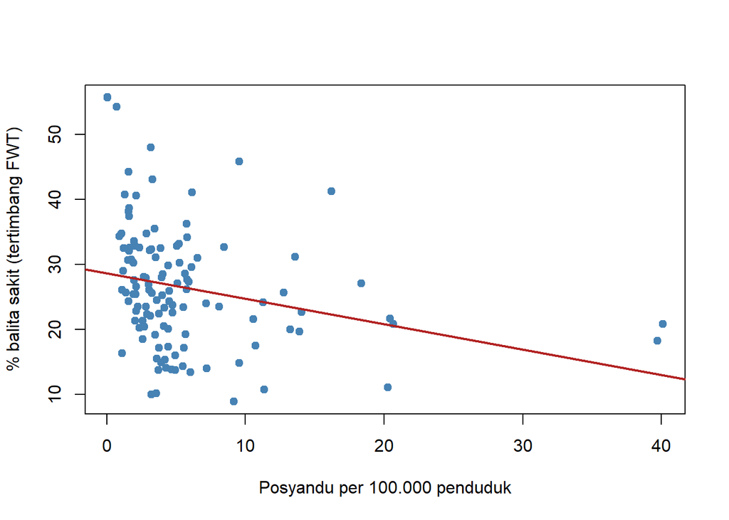

```r
plot(data_kab$posyandu_per_100k, data_kab$pct_balita_sakit,
     xlab = "Posyandu per 100.000 penduduk",
     ylab = "% balita sakit (tertimbang FWT)",
     pch = 19, col = "steelblue")
abline(lm(pct_balita_sakit ~ posyandu_per_100k, data = data_kab),
       col = "firebrick", lwd = 2)
```

Dan regresi sederhananya:

```r
summary(lm(pct_balita_sakit ~ posyandu_per_100k, data = data_kab))
```

```
Call:
lm(formula = pct_balita_sakit ~ posyandu_per_100k, data = data_kab)

Residuals:
     Min       1Q   Median       3Q      Max
-17.3897  -6.4269  -0.4881   4.9274  27.0829

Coefficients:
                  Estimate Std. Error t value Pr(>|t|)
(Intercept)        28.6510     1.1375  25.188  < 2e-16 ***
posyandu_per_100k  -0.3923     0.1365  -2.873  0.00483 **
---
Signif. codes:  0 '***' 0.001 '**' 0.01 '*' 0.05 '.' 0.1 ' ' 1

Residual standard error: 9.179 on 117 degrees of freedom
Multiple R-squared:  0.06589,   Adjusted R-squared:  0.05791
F-statistic: 8.253 on 1 and 117 DF,  p-value: 0.004831
```

# 6 Analisa OLS dengan variabel lengkap

Bagian sebelumnya hanya memakai dua variabel contoh. Dengan pola yang sama, seluruh variabel lain dapat dikonstruksi (skrip `03`–`09`) lalu digabungkan (skrip `10`) menjadi basis data `Hasil_Agregasi_DTA/data_kabupaten_jawa.dta` — 119 kabupaten/kota dengan indikator SUSENAS dan PODES lengkap. Bagian ini memakai basis data tersebut untuk analisa OLS.

## 6.1 Baca basis data dan siapkan variabel

```r
data_jawa <- read_dta("Hasil_Agregasi_DTA/data_kabupaten_jawa.dta") %>%
  mutate(kota = as.integer(tipe == 2))   # dummy: 1 = Kota, 0 = Kabupaten

dim(data_jawa)
```

```
[1] 119  16
```

```r
names(data_jawa)
```

```
 [1] "kode_kab"              "nama_kab"              "provinsi"
 [4] "tipe"                  "populasi"              "pct_balita_sakit"
 [7] "pct_imunisasi"         "pct_keluarga_merokok"  "pct_ortu_merokok"
[10] "mean_pendidikan_ibu"   "mean_pengeluaran_susu" "jumlah_posyandu"
[13] "posyandu_per_100k"     "total_faskes"          "faskes_per_100k"
[16] "kota"
```

**Model yang disarankan** — determinan kesehatan balita antar kabupaten:

$$\text{pct\_balita\_sakit}_i = \beta_0 + \beta_1\,\text{pct\_imunisasi}_i + \beta_2\,\text{pct\_keluarga\_merokok}_i + \beta_3\,\text{mean\_pendidikan\_ibu}_i + \beta_4\,\text{faskes\_per\_100k}_i + \beta_5\,\text{kota}_i + \varepsilon_i$$

Ekspektasi tanda koefisien: imunisasi (−), keluarga merokok (+), pendidikan ibu (−), faskes per kapita (−).

## 6.2 Eksplorasi sebelum regresi

Selalu mulai dari statistik deskriptif dan korelasi:

```r
data_jawa %>%
  select(pct_balita_sakit, pct_imunisasi, pct_keluarga_merokok,
         mean_pendidikan_ibu, faskes_per_100k, kota) %>%
  summary()
```

```
 pct_balita_sakit pct_imunisasi   pct_keluarga_merokok mean_pendidikan_ibu
 Min.   : 8.875   Min.   :29.90   Min.   :32.36        Min.   :1.434
 1st Qu.:20.321   1st Qu.:48.03   1st Qu.:48.53        1st Qu.:2.283
 Median :25.655   Median :54.91   Median :53.91        Median :2.618
 Mean   :26.452   Mean   :55.98   Mean   :53.68        Mean   :2.601
 3rd Qu.:32.222   3rd Qu.:64.33   3rd Qu.:59.98        3rd Qu.:2.876
 Max.   :55.712   Max.   :82.76   Max.   :72.83        Max.   :4.568
 faskes_per_100k       kota
 Min.   : 1.155   Min.   :0.0000
 1st Qu.: 3.948   1st Qu.:0.0000
 Median : 6.374   Median :0.0000
 Mean   : 9.282   Mean   :0.2857
 3rd Qu.: 9.525   3rd Qu.:1.0000
 Max.   :67.993   Max.   :1.0000
```

**Cara membaca:** persentase balita sakit sangat bervariasi antar kabupaten — dari sekitar 9% sampai 56%, dengan rata-rata ±26%. Variasi yang lebar ini justru bagus untuk regresi: ada “sesuatu” yang perlu dijelaskan. Cakupan imunisasi juga beragam (30–83%), begitu pula rasio faskes (1–68 per 100 ribu penduduk — nilai maksimum yang jauh dari kuartil 3 menandakan ada *outlier*, kemungkinan kota kecil berpenduduk sedikit).

```r
round(cor(data_jawa %>%
  select(pct_balita_sakit, pct_imunisasi, pct_keluarga_merokok,
         mean_pendidikan_ibu, faskes_per_100k)), 2)
```

```
                     pct_balita_sakit pct_imunisasi pct_keluarga_merokok
pct_balita_sakit                 1.00         -0.45                 0.24
pct_imunisasi                   -0.45          1.00                -0.15
pct_keluarga_merokok             0.24         -0.15                 1.00
mean_pendidikan_ibu             -0.52          0.61                -0.16
faskes_per_100k                 -0.24          0.39                -0.14
                     mean_pendidikan_ibu faskes_per_100k
pct_balita_sakit                   -0.52           -0.24
pct_imunisasi                       0.61            0.39
pct_keluarga_merokok               -0.16           -0.14
mean_pendidikan_ibu                 1.00            0.23
faskes_per_100k                     0.23            1.00
```

**Cara membaca:** baris/kolom pertama menunjukkan korelasi outcome dengan tiap prediktor — semuanya searah dugaan: negatif dengan imunisasi (−0,45) dan pendidikan ibu (−0,52), positif dengan keluarga merokok (+0,24). Perhatikan juga korelasi **antar prediktor**: imunisasi × pendidikan ibu mencapai 0,61 — sinyal awal multikolinearitas yang nanti kita konfirmasi dengan VIF.

## 6.3 Visualisasi deskriptif

Angka ringkasan perlu didampingi gambar — sebaran, perbandingan antar kelompok, dan hubungan antar variabel jauh lebih cepat terbaca secara visual.

**(a) Sebaran outcome.** Histogram memperlihatkan bentuk sebaran % balita sakit antar 119 kabupaten/kota (garis putus-putus = rata-rata):

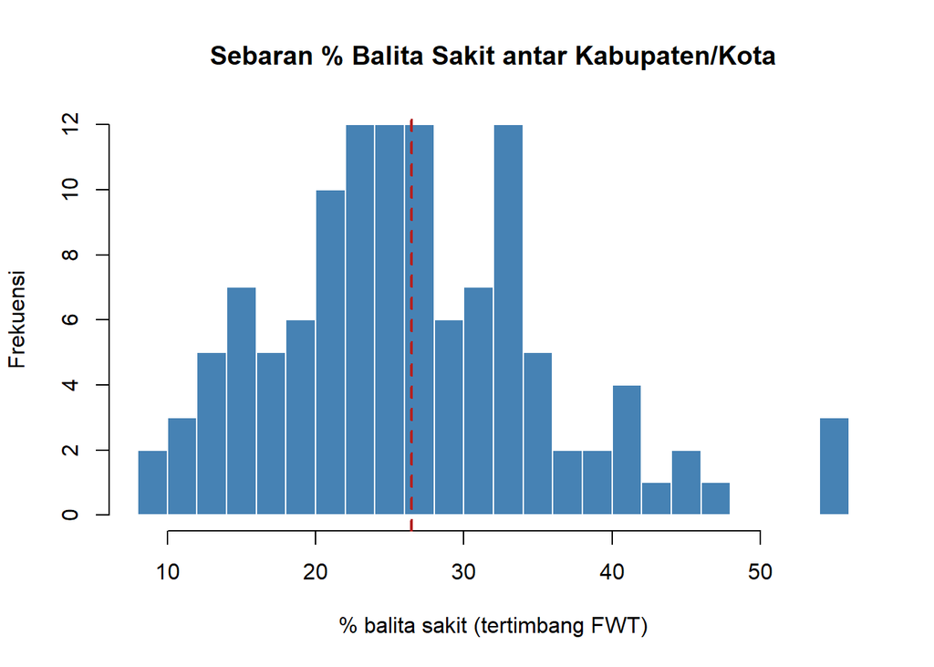

```r
hist(data_jawa$pct_balita_sakit,
     breaks = 20, col = "steelblue", border = "white",
     main   = "Sebaran % Balita Sakit antar Kabupaten/Kota",
     xlab   = "% balita sakit (tertimbang FWT)", ylab = "Frekuensi")
abline(v = mean(data_jawa$pct_balita_sakit), col = "firebrick",
       lwd = 2, lty = 2)
```

**Cara membaca:** sebaran cenderung simetris dengan puncak di sekitar 20–30% dan ekor kanan yang memanjang — beberapa kabupaten punya persentase balita sakit jauh di atas rata-rata (garis putus-putus merah). Tidak ada indikasi sebaran ekstrem yang menuntut transformasi (mis. log) pada outcome.

**(b) Perbandingan antar provinsi.** Boxplot menunjukkan variasi antar dan di dalam provinsi:

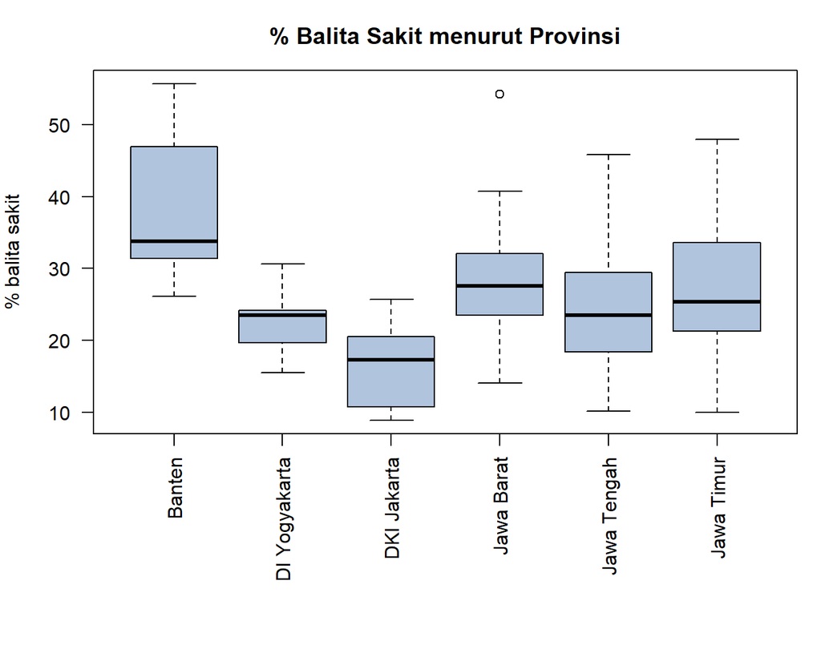

```r
par(mar = c(9, 4, 3, 1))
boxplot(pct_balita_sakit ~ provinsi, data = data_jawa,
        col  = "lightsteelblue", las = 2, xlab = "",
        main = "% Balita Sakit menurut Provinsi",
        ylab = "% balita sakit")
```

```r
par(mar = c(5, 4, 4, 2))
```

**(c) Kabupaten vs kota.** Apakah wilayah perkotaan berbeda?

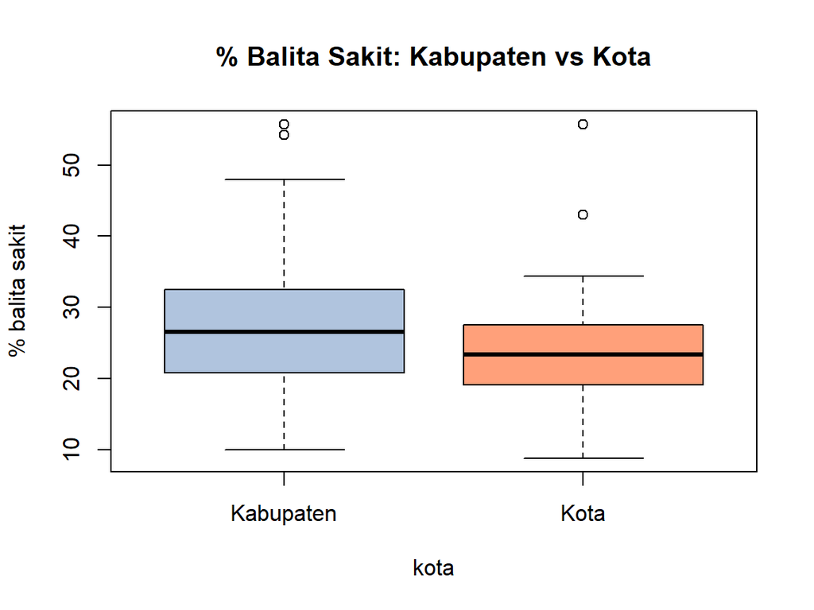

```r
boxplot(pct_balita_sakit ~ kota, data = data_jawa,
        names = c("Kabupaten", "Kota"),
        col   = c("lightsteelblue", "lightsalmon"),
        main  = "% Balita Sakit: Kabupaten vs Kota",
        ylab  = "% balita sakit")
```

**Cara membaca:** kota sedikit lebih rendah daripada kabupaten (rata-rata ±24% vs ±27%), tetapi kedua kotak masih banyak tumpang tindih — perbedaannya tidak dramatis. Ini konsisten dengan hasil regresi nanti: koefisien dummy `kota` bertanda negatif tetapi tidak signifikan.

**(d) Matriks scatterplot.** Semua pasangan variabel sekaligus — baris pertama memperlihatkan hubungan outcome dengan tiap prediktor, sel-sel lainnya memperlihatkan korelasi **antar prediktor** (bahan diskusi multikolinearitas):

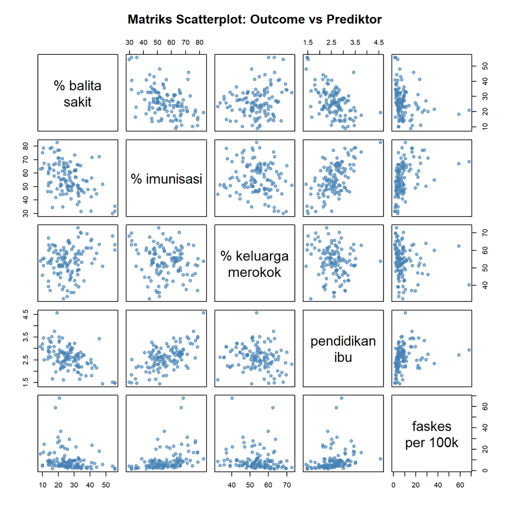

```r
pairs(data_jawa[, c("pct_balita_sakit", "pct_imunisasi",
                    "pct_keluarga_merokok", "mean_pendidikan_ibu",
                    "faskes_per_100k")],
      labels = c("% balita\nsakit", "% imunisasi", "% keluarga\nmerokok",
                 "pendidikan\nibu", "faskes\nper 100k"),
      pch = 19, col = adjustcolor("steelblue", 0.6),
      main = "Matriks Scatterplot: Outcome vs Prediktor")
```

**Cara membaca:** fokus ke baris pertama — pola menurun terlihat pada imunisasi dan pendidikan ibu (hubungan negatif dengan outcome), pola menaik samar pada keluarga merokok. Di luar baris pertama, panel imunisasi × pendidikan ibu memperlihatkan pola menaik yang cukup rapat: inilah wujud visual korelasi 0,61 antar prediktor tadi.

## 6.4 Model 1: regresi sederhana

```r
ols1 <- lm(pct_balita_sakit ~ pct_imunisasi, data = data_jawa)
summary(ols1)
```

```
Call:
lm(formula = pct_balita_sakit ~ pct_imunisasi, data = data_jawa)

Residuals:
     Min       1Q   Median       3Q      Max
-18.1976  -5.2648  -0.3567   4.3136  25.4558

Coefficients:
              Estimate Std. Error t value Pr(>|t|)
(Intercept)   47.37559    3.87524  12.225  < 2e-16 ***
pct_imunisasi -0.37376    0.06782  -5.511 2.16e-07 ***
---
Signif. codes:  0 '***' 0.001 '**' 0.01 '*' 0.05 '.' 0.1 ' ' 1

Residual standard error: 8.462 on 117 degrees of freedom
Multiple R-squared:  0.2061,    Adjusted R-squared:  0.1993
F-statistic: 30.37 on 1 and 117 DF,  p-value: 2.157e-07
```

**Cara membaca:** setiap kenaikan 1 poin persen cakupan imunisasi berasosiasi dengan penurunan % balita sakit sebesar ±0,37 poin (p < 0,001). R² = 0,21 artinya imunisasi sendirian “menjelaskan” sekitar 21% variasi antar kabupaten. Tetapi ingat: model satu variabel rawan *omitted variable bias* — koefisien ini masih “menampung” efek variabel lain yang berkorelasi dengan imunisasi (terutama pendidikan ibu).

## 6.5 Model 2: regresi berganda

```r
ols2 <- lm(pct_balita_sakit ~ pct_imunisasi + pct_keluarga_merokok +
             mean_pendidikan_ibu + faskes_per_100k + kota,
           data = data_jawa)
summary(ols2)
```

```
Call:
lm(formula = pct_balita_sakit ~ pct_imunisasi + pct_keluarga_merokok +
    mean_pendidikan_ibu + faskes_per_100k + kota, data = data_jawa)

Residuals:
     Min       1Q   Median       3Q      Max
-22.1456  -4.8483  -0.3046   4.8743  25.5115

Coefficients:
                     Estimate Std. Error t value Pr(>|t|)
(Intercept)          44.34234    6.73183   6.587 1.48e-09 ***
pct_imunisasi        -0.16284    0.08533  -1.908 0.058882 .
pct_keluarga_merokok  0.16626    0.08666   1.918 0.057576 .
mean_pendidikan_ibu  -6.43909    1.81798  -3.542 0.000578 ***
faskes_per_100k      -0.03965    0.08229  -0.482 0.630839
kota                 -2.04015    1.67600  -1.217 0.226036
---
Signif. codes:  0 '***' 0.001 '**' 0.01 '*' 0.05 '.' 0.1 ' ' 1

Residual standard error: 7.895 on 113 degrees of freedom
Multiple R-squared:  0.3325,    Adjusted R-squared:  0.303
F-statistic: 11.26 on 5 and 113 DF,  p-value: 8.012e-09
```

```r
confint(ols2)
```

```
                             2.5 %      97.5 %
(Intercept)           31.005363102 57.67931894
pct_imunisasi         -0.331885358  0.00621379
pct_keluarga_merokok  -0.005435889  0.33796023
mean_pendidikan_ibu  -10.040830900 -2.83734238
faskes_per_100k       -0.202676929  0.12337538
kota                  -5.360613229  1.28030744
```

**Cara membaca:** semua tanda koefisien sesuai ekspektasi. Prediktor terkuat adalah **pendidikan ibu**: naik satu jenjang rata-rata pendidikan ibu berasosiasi dengan turunnya % balita sakit ±6,4 poin (p < 0,001) — konsisten dengan temuan umum literatur kesehatan anak. Imunisasi (−0,16) dan keluarga merokok (+0,17) berada di ambang signifikansi (p ≈ 0,06), sedangkan faskes per kapita dan dummy kota tidak signifikan setelah variabel lain dikendalikan. Interval kepercayaan (`confint`) yang memuat nol menandai koefisien yang tidak signifikan pada taraf 5%.

**NoteMomen didaktik: omitted variable bias**

Koefisien `pct_imunisasi` menyusut dari -0.37 (Model 1) menjadi -0.16 (Model 2). Sebabnya: imunisasi berkorelasi kuat dengan pendidikan ibu, sehingga pada model sederhana sebagian efek pendidikan “menumpang” pada koefisien imunisasi. Inilah ilustrasi klasik *omitted variable bias*.

## 6.6 Diagnostik OLS

Empat plot diagnostik standar:

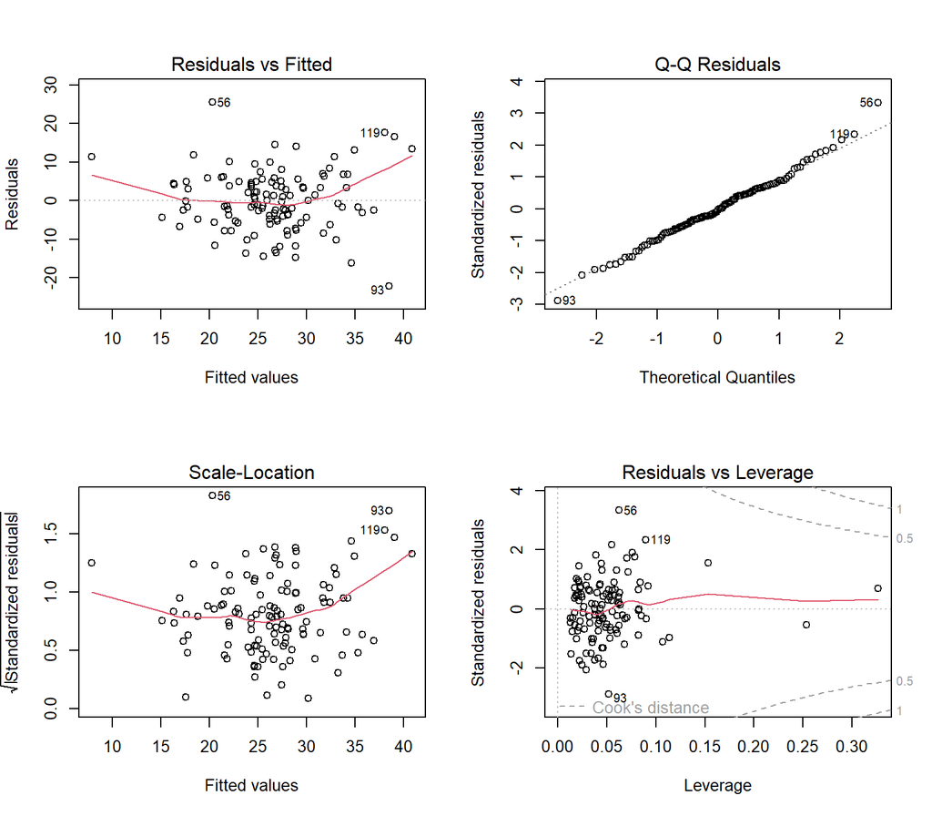

```r
par(mfrow = c(2, 2))
plot(ols2)
```

```r
par(mfrow = c(1, 1))
```

**Multikolinearitas (VIF)** — paket `car` (pasang dengan `install.packages("car")` bila belum ada):

```r
library(car)
vif(ols2)
```

```
       pct_imunisasi pct_keluarga_merokok  mean_pendidikan_ibu
            1.818361             1.046816             1.651193
     faskes_per_100k                 kota
            1.263748             1.094486
```

**Cara membaca:** semua VIF di bawah 2 (tertinggi imunisasi ±1,8) — jauh dari ambang masalah (rule of thumb: VIF > 10 serius, > 5 perlu waspada). Jadi walau imunisasi dan pendidikan ibu berkorelasi 0,61, kolinearitasnya belum mengganggu presisi estimasi; kedua variabel aman dipertahankan dalam satu model.

**Heteroskedastisitas (uji Breusch-Pagan)** — paket `lmtest`:

```r
library(lmtest)
bptest(ols2)
```

```
    studentized Breusch-Pagan test

data:  ols2
BP = 7.2642, df = 5, p-value = 0.2017
```

**Cara membaca:** p-value = 0,20 > 0,05 → gagal tolak H0 varians residual konstan (homoskedastis). *Standard error* OLS biasa dapat dipakai; robust standard error (paket `sandwich`, `vcovHC`) tidak wajib di sini — tetapi tetap praktik yang baik untuk data riil.

## 6.7 Perbandingan model

```r
cat("R-squared model 1 :", round(summary(ols1)$r.squared, 3), "\n")
```

```
R-squared model 1 : 0.206
```

```r
cat("R-squared model 2 :", round(summary(ols2)$r.squared, 3), "\n")
```

```
R-squared model 2 : 0.333
```

**Cara membaca:** R² naik dari 0,21 menjadi 0,33 — penambahan empat variabel menjelaskan tambahan ±13 poin persen variasi outcome. Sisanya (±67%) tak terjelaskan model: wajar untuk data lintas-wilayah, dan menjadi pengingat bahwa R² tinggi bukan tujuan utama — yang penting spesifikasi masuk akal dan koefisien dapat diinterpretasikan.

**Warning**

Ingat: data ini **sintetis** — tanda dan besaran koefisien mengikuti desain generator data, bukan temuan empiris. Gunakan hanya untuk memahami alur kerja dan interpretasi output.

# 7 Rangkuman dan latihan

| Tahap | SUSENAS (survei) | PODES (sensus desa) |
| --- | --- | --- |
| Unit data mentah | individu / rumah tangga | desa |
| Kode wilayah | `paste0(R101, R102)` | `paste0(R101, R102)` |
| Konstruksi | `filter()` + recode + `labelled()` | pilih kolom faskes |
| Agregasi | `weighted.mean(x, w = FWT)` | `sum(x)` |
| Hasil per kabupaten | persentase / rata-rata | jumlah / rasio per penduduk |

**Latihan mandiri** — ulangi seluruh alur untuk variabel lain:

1. *SUSENAS*: imunisasi Hepatitis B (`R1404A_TGL` terisi, file `kor23_ind_2_sintetis.dta`) → % balita terimunisasi per kabupaten.
2. *SUSENAS*: keluarga merokok (`R1206`/`R1207`) — perhatikan agregasi maksimum per rumah tangga sebelum dihitung proporsinya.
3. *PODES*: jumlah puskesmas (`R704CK2 + R704DK2`) per kabupaten, lalu jadikan rasio per 100.000 penduduk.
4. *OLS*: ganti outcome menjadi `pct_imunisasi` — prediktor apa yang masuk akal? Coba juga tambahkan `log(mean_pengeluaran_susu)` sebagai prediktor dan bandingkan hasilnya.

Skrip lengkap seluruh variabel tersedia di folder `Script_R/` (`00_ref_kabupaten_jawa.R` sampai `11_stepbystep_quarto.R` — skrip `11` adalah versi step-by-step yang persis mengikuti hand-out ini).

# Daftar Pustaka

- Badan Pusat Statistik. (2023). *Pedoman Pencacahan Survei Sosial Ekonomi Nasional (SUSENAS) Maret 2023*. Jakarta: BPS.
- Badan Pusat Statistik. (2021). *Pedoman Pendataan Potensi Desa (PODES) 2021*. Jakarta: BPS.
- Fox, J., & Weisberg, S. (2019). *An R Companion to Applied Regression* (3rd ed.). Thousand Oaks, CA: Sage. (paket `car`)
- Lumley, T. (2010). *Complex Surveys: A Guide to Analysis Using R*. Hoboken, NJ: John Wiley & Sons. (paket `survey`)
- R Core Team. (2024). *R: A Language and Environment for Statistical Computing*. Vienna: R Foundation for Statistical Computing. https://www.R-project.org/
- Wickham, H., François, R., Henry, L., Müller, K., & Vaughan, D. (2023). *dplyr: A Grammar of Data Manipulation*. R package. https://dplyr.tidyverse.org
- Wickham, H., & Miller, E. (2023). *haven: Import and Export ‘SPSS’, ‘Stata’ and ‘SAS’ Files*. R package. https://haven.tidyverse.org
- Wooldridge, J. M. (2020). *Introductory Econometrics: A Modern Approach* (7th ed.). Boston, MA: Cengage Learning.
- Zeileis, A., & Hothorn, T. (2002). Diagnostic checking in regression relationships. *R News*, 2(3), 7–10. (paket `lmtest`)

**Pengingat terakhir:** seluruh materi ini menggunakan data sintetis untuk pelatihan — bukan data resmi BPS dan tidak menggambarkan kondisi riil wilayah mana pun.